# Equity Matrix (EQM) algorithm

Bruno A Lima

2023-05-06

## Objectivo

Definir uma matriz de equidade que seja aplicável à seleção do par dador receptor em transplantação renal.

## Métodos

Para esta análise foram gerados dados sintéticos para um lista de espera simulada de 2000 candidatos a transplante com a respectiva informação clinica, imunológica e demográfica. Neste exercício, não foram gerados candidatos classificados como clinicamente urgentes.

Também foram gerados dados demográficos e imunológicos para um conjunto de 280 dadores de rim.

Os conjuntos de dados foram gerados com o *package* {simK}[^1]:

```
cndts <- simK::candidates_df(n = 2000,
                          replace = TRUE,
                          origin = 'PT',
                          probs.abo = c(0.43, 0.03, 0.08, 0.46),
                          probs.cpra = c(0.7, 0.1, 0.1, 0.1),
                          lower=18, upper=75,
                          mean = 45, sd = 15,
                          prob.dm = 0.12,
                          prob.urgent = 0,
                          uk = FALSE,
                          seed.number = 3) |>
          dplyr::select(ID, bg, A1, A2, B1, B2, DR1, DR2, age, dialysis, cPRA, urgent)

antbs <- simK::Abs_df(candidates = cds,
                    origin = 'PT',
                    seed.number = 3)

dnrs <- simK::donors_df(n = 280,
                      replace = TRUE,
                      origin = 'PT',
                      probs = c(0.4658, 0.0343, 0.077, 0.4229),
                      lower=18, upper=75,
                      mean = 60, sd = 12,
                      uk = FALSE,
                      seed.number = 3)
```

### Descrição

Foram usados os algoritmos de alocação `lima()`, `et()` e `eqm()` disponíveis através do *package* {histoc}[^2].

Resumidamente, no modelo **Lima** os candidatos a transplante são classificados em cores de prioridade tendo em conta o respectivo tempo de diálise e o valor de cPRA: laranja para os doentes com cPRA > 85% ou tempo de diálise > 3º quartil; amarelo para os doentes com cPRa > 50% ou tempo de diálise > mediana; e verdes todos os restantes. Os candidatos são ainda inicialmente distribuidos tendo em conta o Senior Program (SP), ou seja, dadores >= 65 anos são alocados prioritáriamente a doentes >= 65 anos e dadores < 65 anos são alocados prioritáriamente a doentes < 65 (*Senior Program*).

O modelo do EuroTransplant **ET** aplica inicialmente o SP e o programa Acceptable Missmatch (AM) em que é dada prioridade aos candidatos hipersensibilizados. Na seleção do ET são priooriizados também os pares dador-receptor com mmHLA 000, depois a ordenação dos candidatos segue um sistema de pontuação para a alocação dos órgãos.

Nos modelos de **matriz de equidade** são considerados como critérios de utilidade os mmHLA e o matching de longevidade. Para os critérios de justiça são considerados a mediana e o 3º quartil do tempo de diálise bem como os respectivos valores de cPRA, tal como descrito no separador ‘EQM’.

Para a construção das matrizes de equidade testadas, foi assumido um valor máximo de 100 e foram considerados os parâmetros:

- eqm0101: `uj_matx(max.val = 100, ratio.util = 0.1, ratio.just = 0.1)`
- eqm0102: `uj_matx(max.val = 100, ratio.util = 0.1, ratio.just = 0.2)`
- eqm0103: `uj_matx(max.val = 100, ratio.util = 0.1, ratio.just = 0.3)`
- eqm0104: `uj_matx(max.val = 100, ratio.util = 0.1, ratio.just = 0.4)`
- eqm0105: `uj_matx(max.val = 100, ratio.util = 0.1, ratio.just = 0.5)`
- eqm0201: `uj_matx(max.val = 100, ratio.util = 0.2, ratio.just = 0.1)`
- eqm0301: `uj_matx(max.val = 100, ratio.util = 0.3, ratio.just = 0.1)`
- eqm0401: `uj_matx(max.val = 100, ratio.util = 0.4, ratio.just = 0.1)`
- eqm0501: `uj_matx(max.val = 100, ratio.util = 0.5, ratio.just = 0.1)`

Nesta análise e para todos os modelos foi considerado como 3º quartil do tempo de diálise 80 meses e como mediana 60 meses.

A alocação dos 280 dadores é feita selecionando os dois melhores candidatos para cada dador sem repetir os candidatos. Isto é, em cada iteração, para o primeiro dador são atribuidos os dois melhores candidatos (garantindo sempre a compatibilidade ABO e um XM virtual negativo), ao segundo dador são atribuidos os 2 melhores candidatos sobrantes (sem os atribuidos a dadores anteriores) e assim sucessivamente até serem atribuidos um máximo de 560 candidatos (2 x 280). Para garantir que a ordenação dos dadores não influencia os resultados, foram feitas até 1000 iterações em que para cada uma das iterações a ordem dos dadores para os quais são atribuidos os candidatos é alterada aleatoriamente.

Assim, para cada iteração é possível calcular valores médios das características dos candidatos seleccionados pelos modelos e construir as distribuições desses valores médios.

### EQM

#### Utility *vs* Justice

Duma forma geral, os princípios éticos que guiam a alocação de rins em transplantação são a utilidade e justiça. Se por um lado se pretende garantir um acesso justo e igual para todos os candidatos a transplante, por outro, deve-se promover uma alocação eficiente, ou seja, assegurar a utilidade do transplante. Assim, distinguimos como critérios:

- de utilidade:
  - *matching* de longevidade;
  - *matching* HLA;
- de justiça:
  - tempo de espera em diálise;
  - sensibilização HLA;
  - prévio dador vivo;
  - minorias étnicas;
  - prioridade pediátrica;
  - urgência médica.

#### EQM

De forma a equilibrar critérios de utilidade com critérios de justiça, a construção da matriz de equidade é feita através da função `histco::uj_matx()` considerando dois parâmetros:

- `ratio.util` - *A numerical value between 0 and 0.5 corresponding to the decreasing rate for the utility criterion (by row);*
- `ratio.just` - *A numerical value between 0 and 0.5 corresponding to the decreasing rate for the justice criterion (by column).*

Assim, a partir de um valor máximo inicial (geralmente 100), os valores por linha são obtidos subtraindo consecutivamente o peso dado à utilidade (Max * `ratio.util`), enquanto que aos valores por coluna é subtratido o peso dos critérios de justiça (MAX * `ratio.just`).

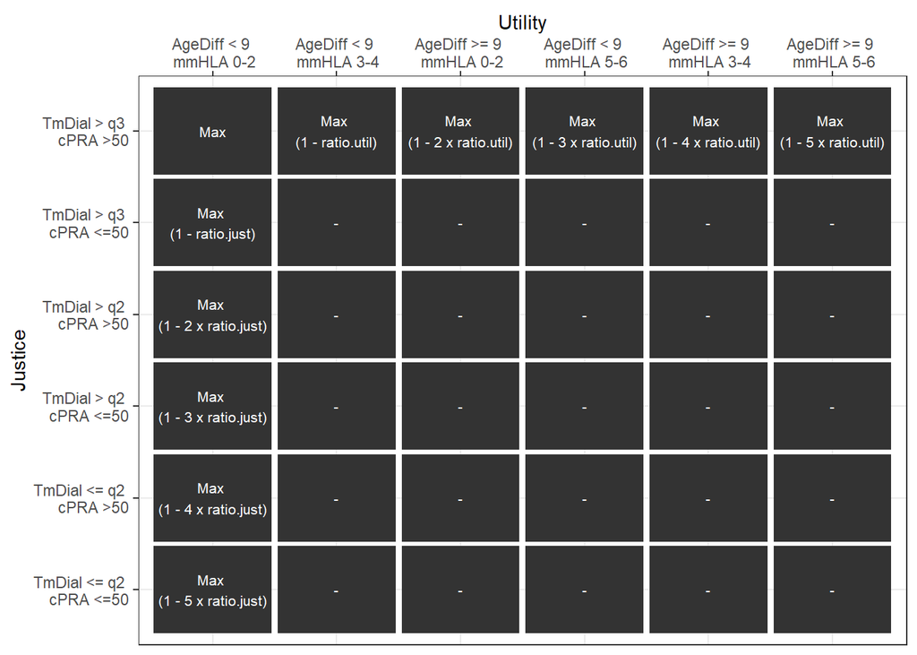

Como critérios de utilidade são considerados os mismatchs HLA (mmHLA) entre dador e receptor bem com um matching de longevidade obtido a partir da diferença absoluta entre as idades de dador e receptor (AgeDiff = |idade dador - idade receptor|). Com estes valores é obtida uma escala com 6 opções.

Como critérios de justiça são considerados o tempo em diálise (TmDial) dos candidatos a tranplante e os seus repectivos valores de cPRA. O TmDial é dividido de acordo com a mediana (q2) e 3º quartil (q3) dos tempos de diálise de todos os candidatos a transplante em análise, obtendo-se três grupos: TmDial > q3; q2 < TmDial <= q3; TmDial <= q2. Os valores de cPRA são dicotomizados no valor 50 (isto é, cPRA > 50 vs cPRA <= 50). Da combinação destes dois grupos é obtida uma uma escala com 6 opções.  
Assim, temos uma matriz de equidade final com 36 (6x6) valores.

Por exemplo, para um `ratio.util = 0.1` e `ratio.just = 0.1`, obtemos a matriz de equidade:

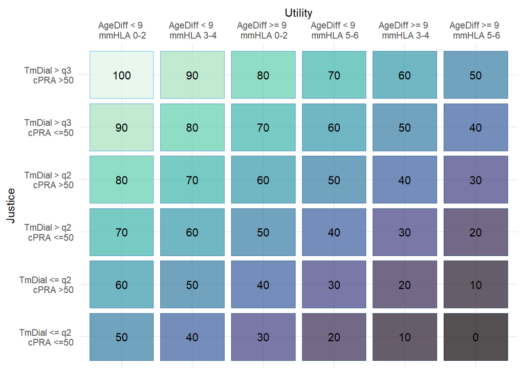

para um `ratio.util = 0.4` e `ratio.just = 0.1`, temos:

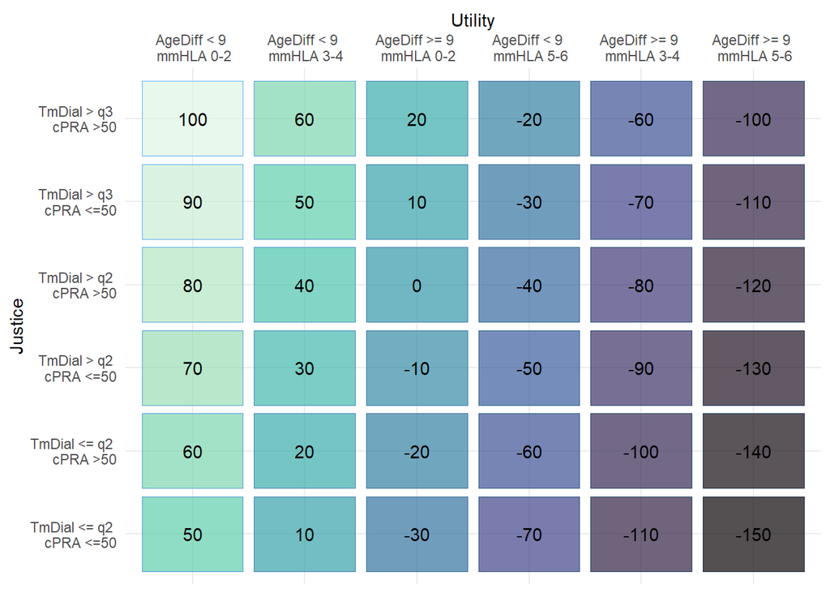

para um `ratio.util = 0.1` e `ratio.just = 0.4`, temos:

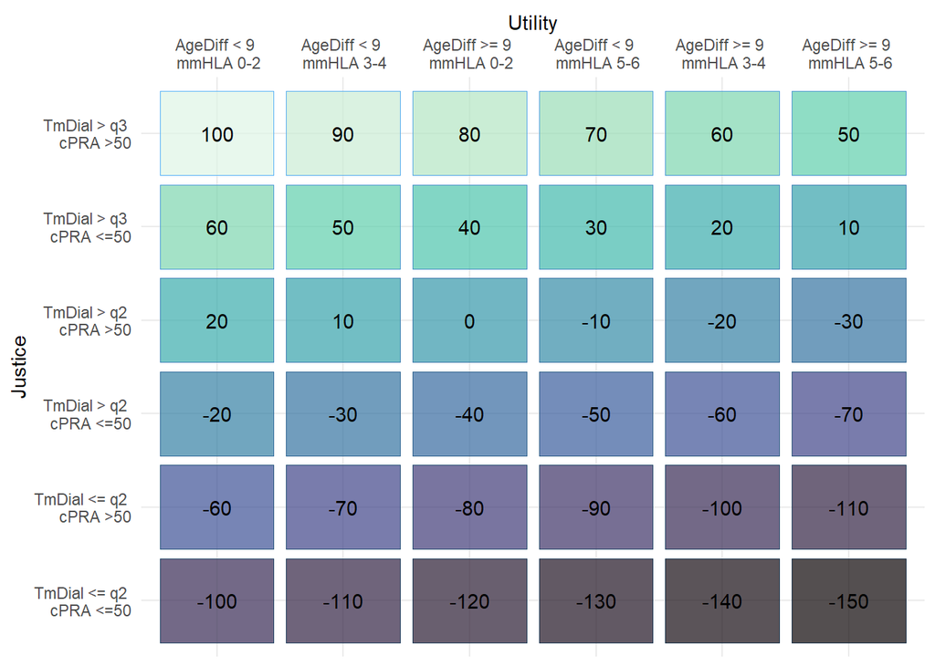

## Resultados

A comparação dos valores médios das caracteisticas dos receptores obtidos para cada iteração e para cada modelo de alocação é feito através da representação gráfica das suas distribuições.

### Idade

As matrizes que dão maior peso à utilidade (eqm0201, eqm0301, eqm0401 e eqm0501) são as que selecionam candidatos mais idosos, ou melhor, candidatos com idades mais próximas aos dadores. Neste exercício as idades dos dadores foram obtidas a partir duma distribuição $\sim N(60,12)$ pelo que é o modelo ‘eqm0501’ que seleciona candidatos com as idades mais próximas às dos dadores. No caso do modelo ‘Lima’ como a idade de candidatos e dadores apenas é considerada para aplicação do *Senior program*, os receptores selecionados não são tão influenciados pelas idades dos dadores.

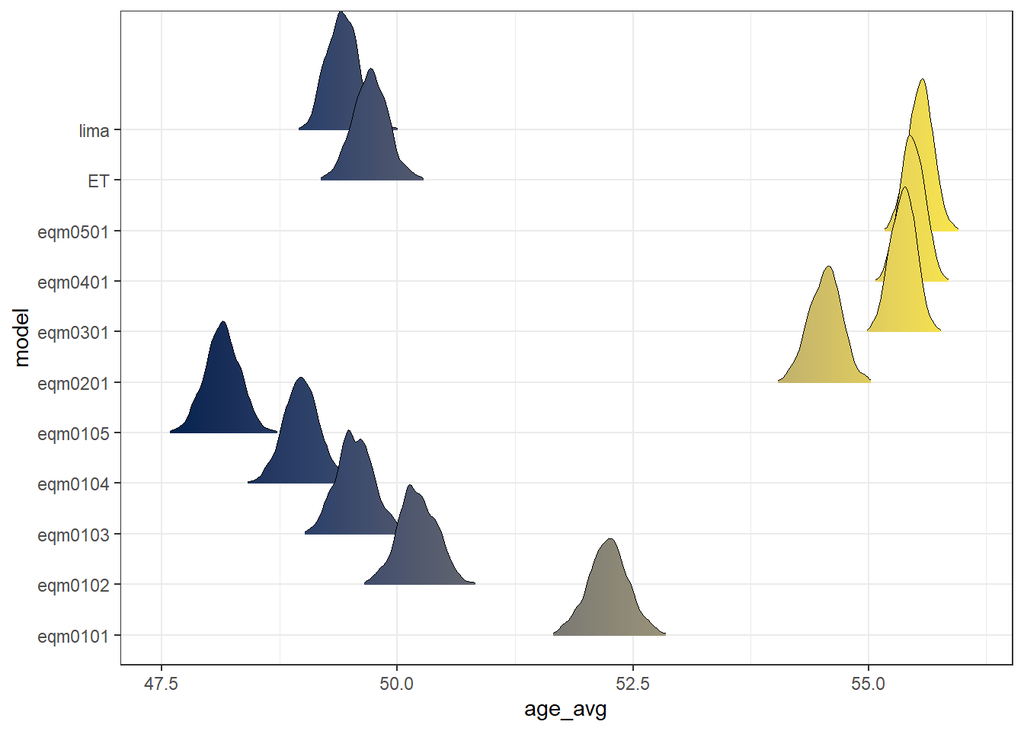

### Diferença de idades

(|idade dador - idade receptor|)

Tal como referido em cima, as matrizes que dão maior peso á utilidade selecionam receptores com idades mais próximas aos dadores, ou seja, com uma diferença de idades entre dador e receptor menor.

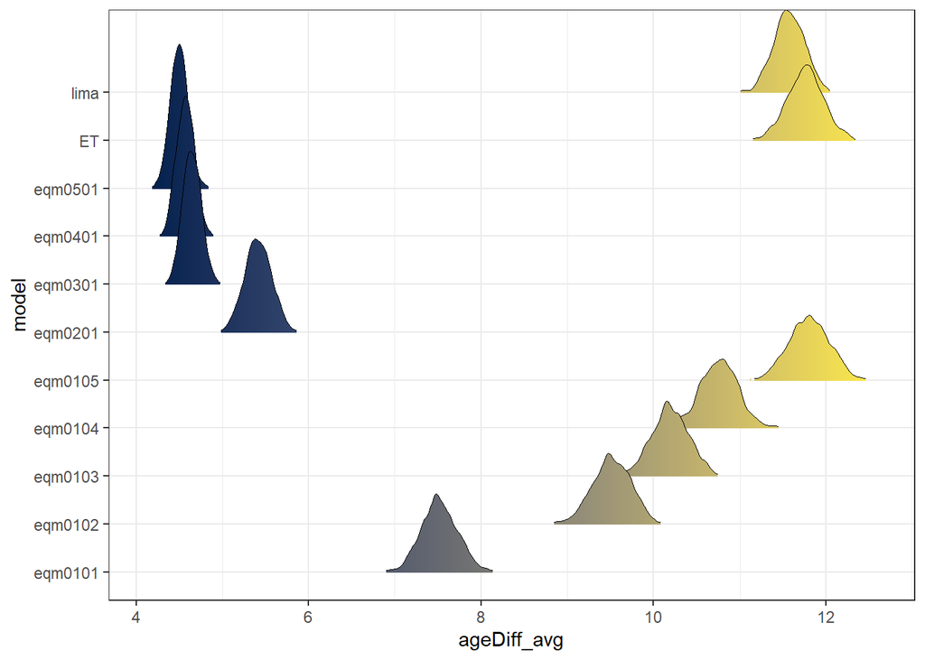

### mmHLA

Para o valor médio do número de mmHLA entre dador e receptor, são as matrizes que dão maior peso à utilidade as que selecionam pares com o menor número de mmHLA (como seria de esperar). Mesmo a matriz mais neutra (eqm0101) seleciona receptores com menos mmHLA que o modelo Lima.

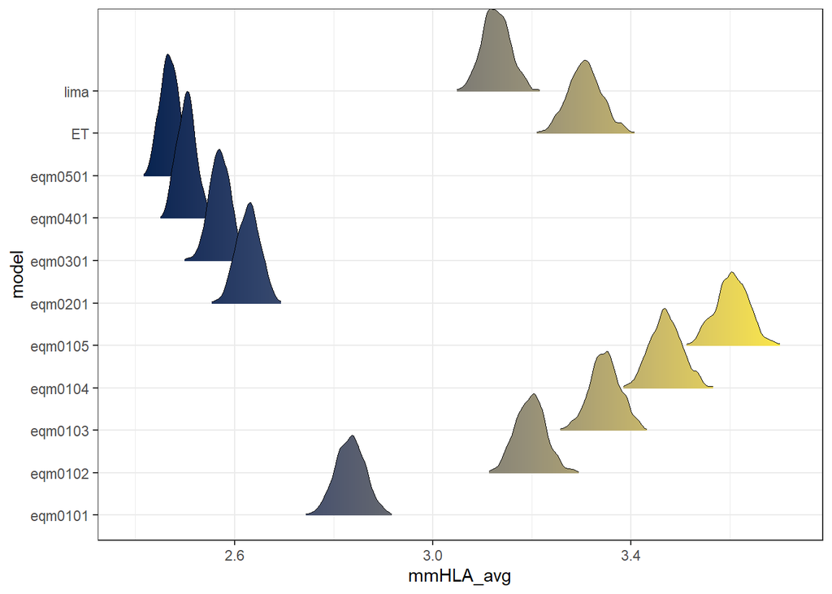

### mmHLA 000 (contagem)

Embora as matrizes que dão mais peso á utilidade selecionem mais receptores com zero mmHLA, este número não difere muito do obtido com o modelo Lima, uma vez que o número de mmHLA total apenas é usado na ordenação final em ambos os modelos.

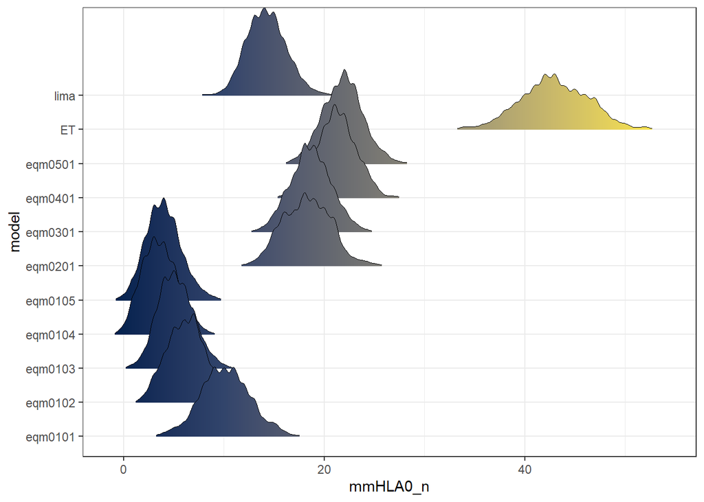

### mmHLA 0-2 (contagem)

Já o número de receptores com até 2 mmHLA é bastante superior na selecção das matrizes que dão maior peso à utilidade e na matriz neutra (eqm0101) em comparação com os receptores do modelo Lima.

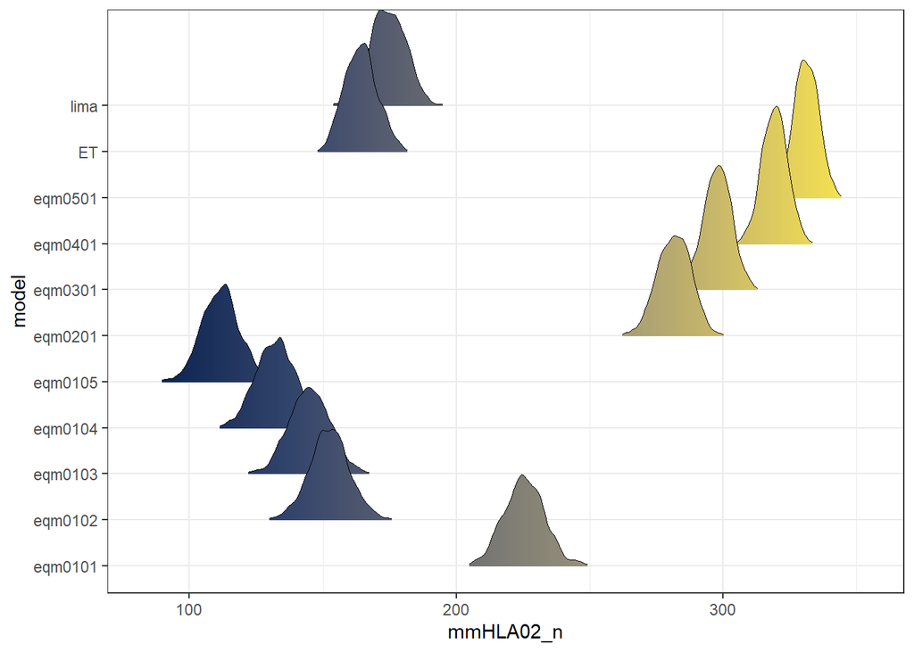

### mmHLA 6 (contagem)

No mesmo sentido, as matrizes que dão maior peso à utilidade selecionam menos receptores com 6 mmHLA.

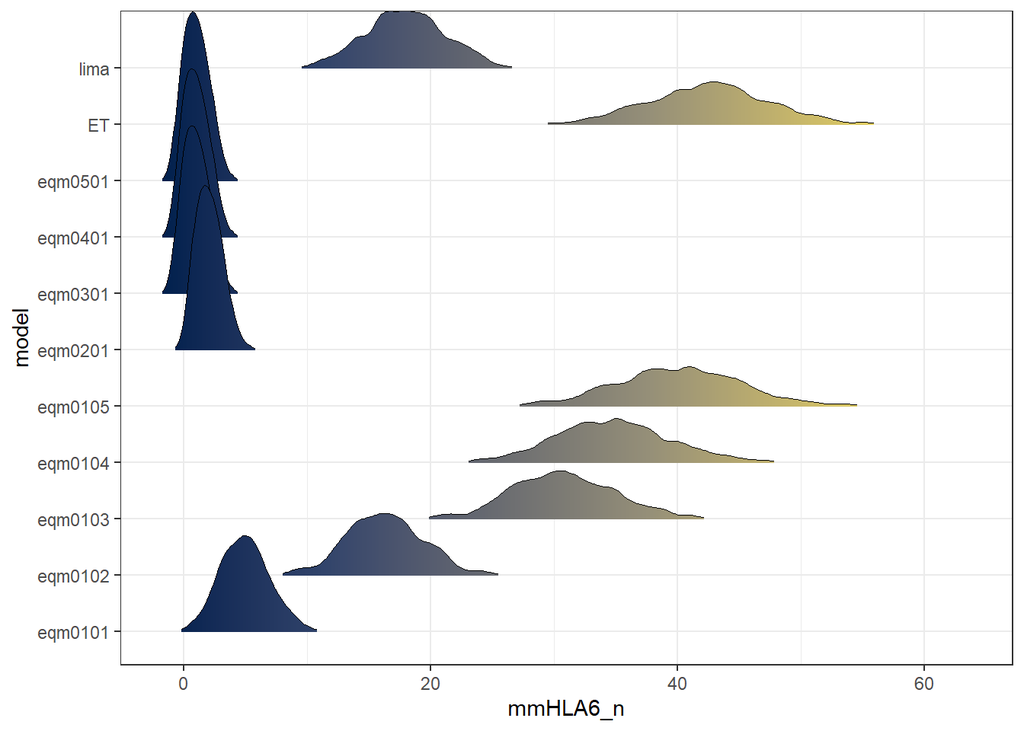

### tempo em diálise (meses)

Como expectável, as matrizes que dão maior peso à justiça (eqm0102, eqm0103, eqm0104, eqm0105) selecionam receptores com maiores tempos em diálise do que o modelo Lima. Ainda assim o modelo Lima ainda consegue seleccionar receptores com maior tempo de diálise que o modelo neutro (eqm0101).

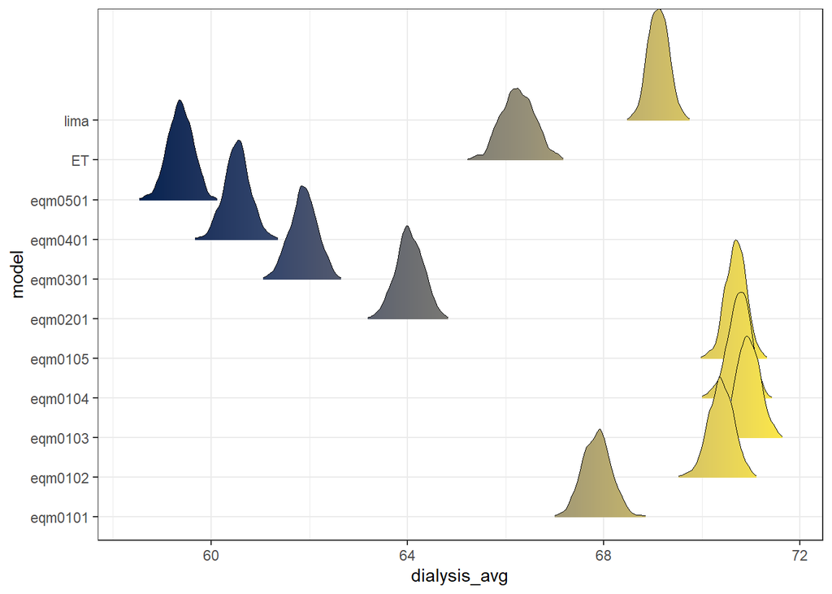

### cPRA (%)

As matrizes que dão amior peso à justiça (por definição) tendem a seleccionar os receptores com valores mais altos de cPRA, sendo que a matriz eqm0102 devolve resultados muito próximos aos obtidos com o modelo Lima.

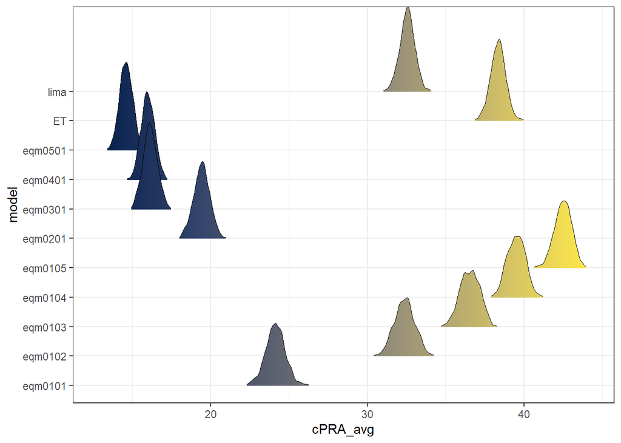

### Hipersensibilizados (contagem)

Qaundo analizamos a contagem de receptores hipersensibilizados, obtemos resultados semelhantes aos descritos para os valores de cPRA.

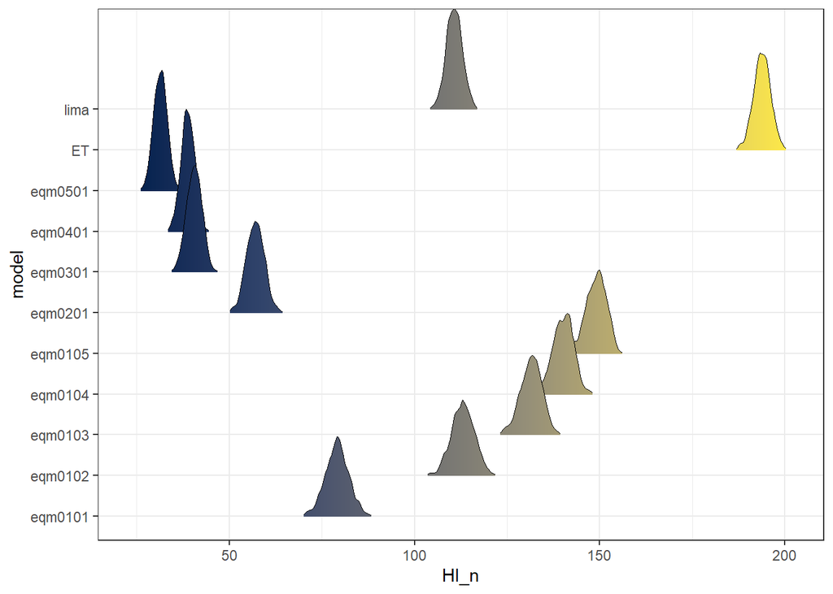

### Senior program (contagem)

Como um dos critérios do modelo Lima é a aplicação das regras do *Senior program* (dadores maiores que 65 anos são alocados prioritariamente a candidatos 65+), o número de receptores 65+ com dadores 65+ é bastante superior no modelo Lima quando comparado com os resultados das matrizes.

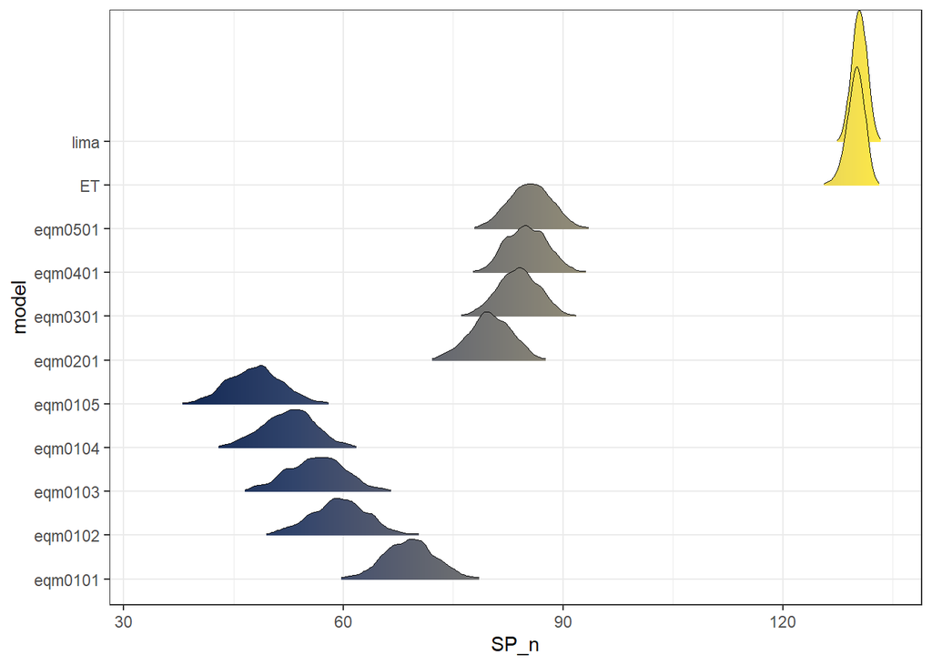

### Tx Score

(*Estimated 5-year event (mortality or graft failure) percentage*)

O cálculo do TxScore[^3] que devolve a percentagem (probabilidade) a 5 anos do evento (morte ou perda do enxerto) foi feito tendo em conta a idade do dador, a idade do receptor, o tempo de diálise e os mmHLA. Para todas as restantes variáveis usadas para o cálculo do TxScore, foram assumidos valores constantes.

Assim, os piores valores são obtidos para o modelo Lima, enquanto que os melhores resultados são dados pelas matrizes que dão maior peso á utilidade.

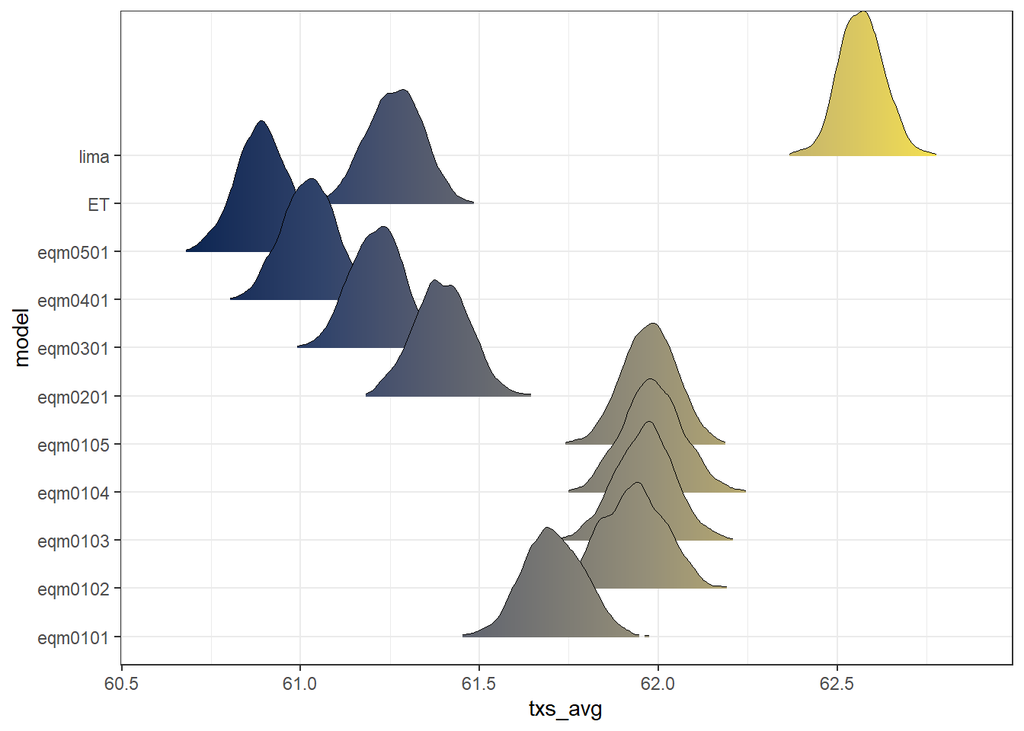

### Resumo

[output not shown]

[^1]: available from: https://github.com/txopen/simK
[^2]: available from: https://github.com/txopen/histoc
[^3]: available from: https://balima.shinyapps.io/scoreTx/